# Análise de dados

Marisangila Alves

08/14/2021

### Parâmetros

alfa igual a $1$ ativa somente migração de servidores, o alfa iguai a $0$ ativa somente migração de caminhos.

```
      Parâmetros      | Valores
----------------------|----------
alfa                  | 0, 0.5, 1
lambda                | 5
n                     | 100
beta                  | 0.2
BS                    | 32
Cache                 | 100
UE                    | 200
Resources             | MBS 50 SBS 25
Average               | MBS 300 SBS 70
RTT inicial           | MBS/MBS 0.001 s MBS/SBS 0.0015 SBS/UE 0.002
Tempo da Requisição   | 10
Mobilidade            | 2
```

### Informações da Aplicação.

```
  Vazão Mínima | Tamanho de Unidade de Cache | Número de Unidades de Cache | Número de Unidades de Recursos
---------------|-----------------------------|-----------------------------|-------------------------------
   45 Mbps     |            169 MB           |             30              |             5
```

### Tempo de execução da otimização.

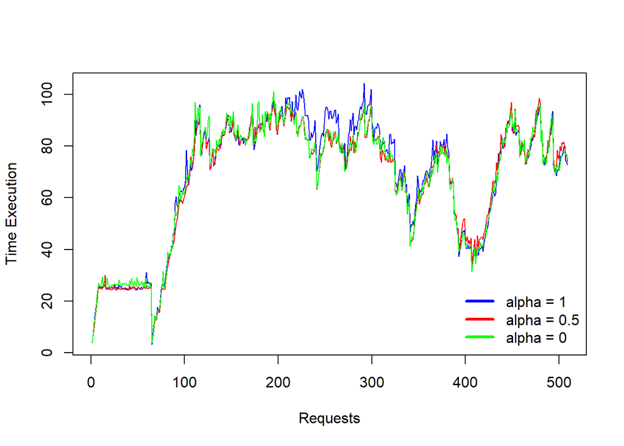

### Distribuição das Requisições.

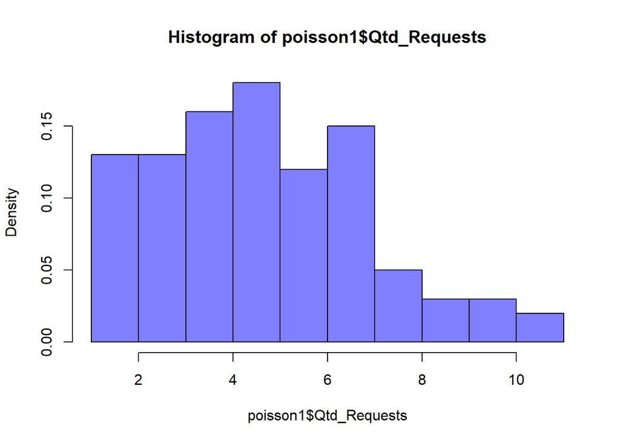

### Distribuição de popularidade do conteúdo solicitado.

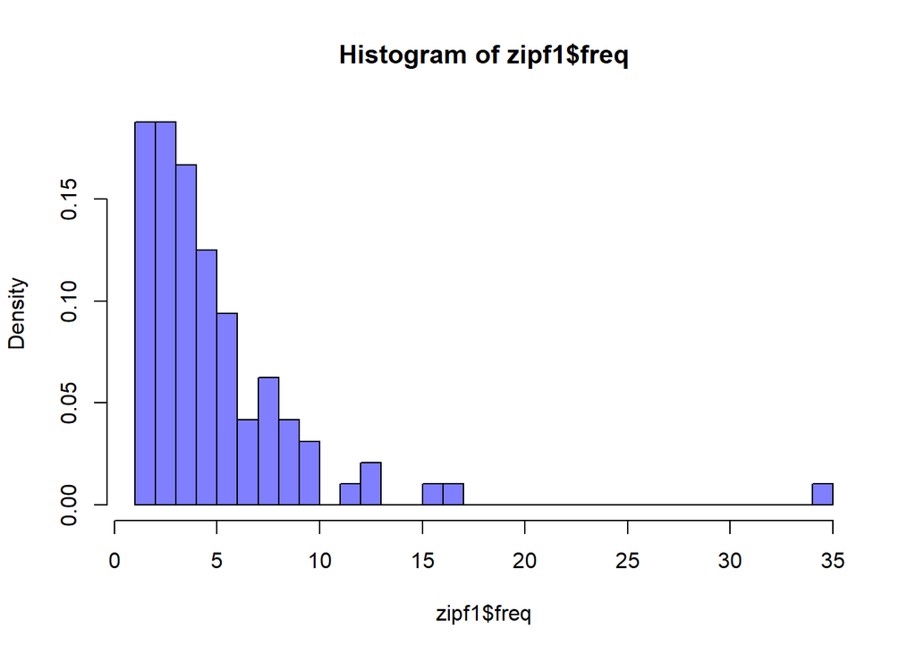

### Taxa de requisições alocadas.

$\alpha : 1 =$ 44.4% - 226/509.

$\alpha : 0.5 =$ 44.4% - 226/509.

$\alpha : 0 =$ 44.4% - 226/509.

### Uso de servidor por evento.

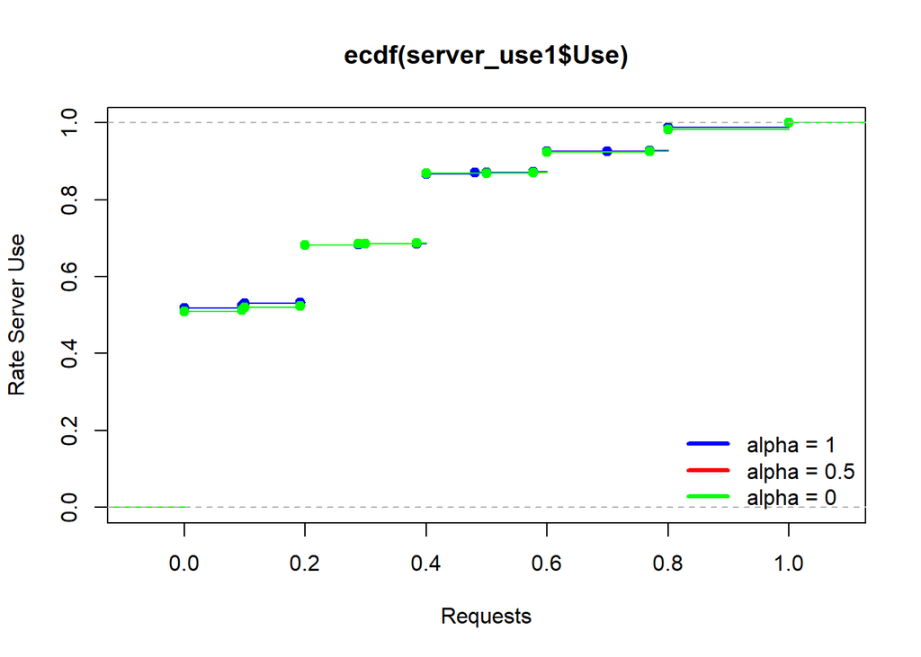

### Fraguimentação de enlaces por evento.

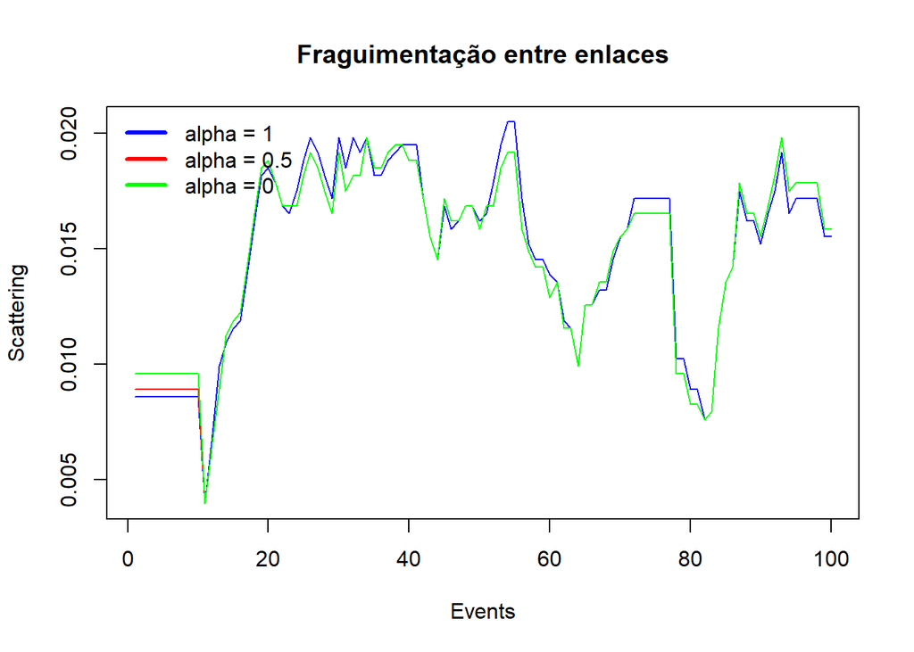

### Significância entre amostras (Teste T não pareado).

*Um valor de p menor que 0.05 indica que a diferença é estatisticamente significativa.*

A diferença entre alfa 1 e alfa 0.5 **não é** estatisticamente significativa. Valor de p: 0.8601807.

A diferença entre alfa 1 e alfa 0 **não é** estatisticamente significativa. Valor de p: 0.8601807.

### Carga média de enlaces por evento.

```
##    Min. 1st Qu.  Median    Mean 3rd Qu.    Max.
##   59.42   64.92   67.41   69.51   72.48   84.35
```

```
##    Min. 1st Qu.  Median    Mean 3rd Qu.    Max.
##   59.42   64.56   66.86   68.88   70.65   83.74
```

```
##    Min. 1st Qu.  Median    Mean 3rd Qu.    Max.
##   59.42   64.56   66.86   68.77   70.65   82.66
```

```
##    Min. 1st Qu.  Median    Mean 3rd Qu.    Max.
##   56.00   56.00   56.00   62.64   68.00   85.00
```

```
##    Min. 1st Qu.  Median    Mean 3rd Qu.    Max.
##   56.00   56.00   65.00   63.69   68.00   85.00
```

```
##    Min. 1st Qu.  Median    Mean 3rd Qu.    Max.
##   56.00   56.00   65.00   63.69   68.00   85.00
```

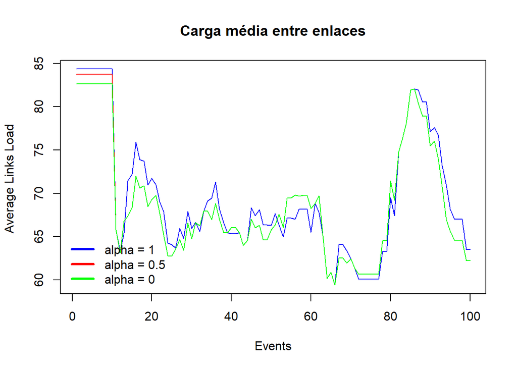

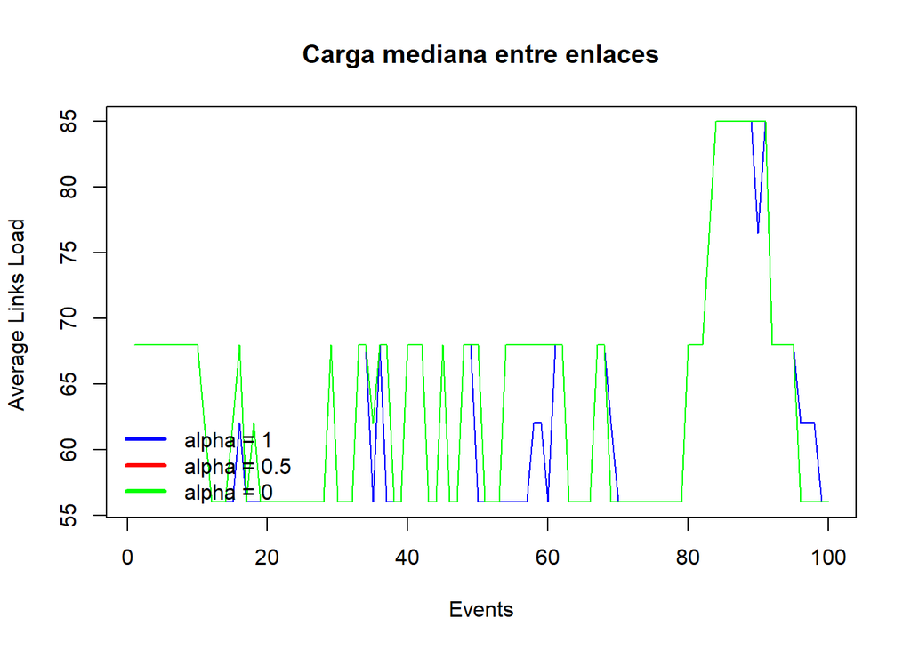

### Significância entre amostras (Teste T não pareado).

*Um valor de p menor que 0.05 indica que a diferença é estatisticamente significativa.*

**Entre médias:**

A diferença entre alfa 1 e alfa 0.5 **não é** estatisticamente significativa. Valor de p: 0.5274124.

A diferença entre alfa 1 e alfa 0 **não é** estatisticamente significativa. Valor de p: 0.4513839.

A diferença entre alfa 0.5 e alfa 0 **não é** estatisticamente significativa. Valor de p: 0.91008.

### Número de Realocação de Enlaces por Requisição

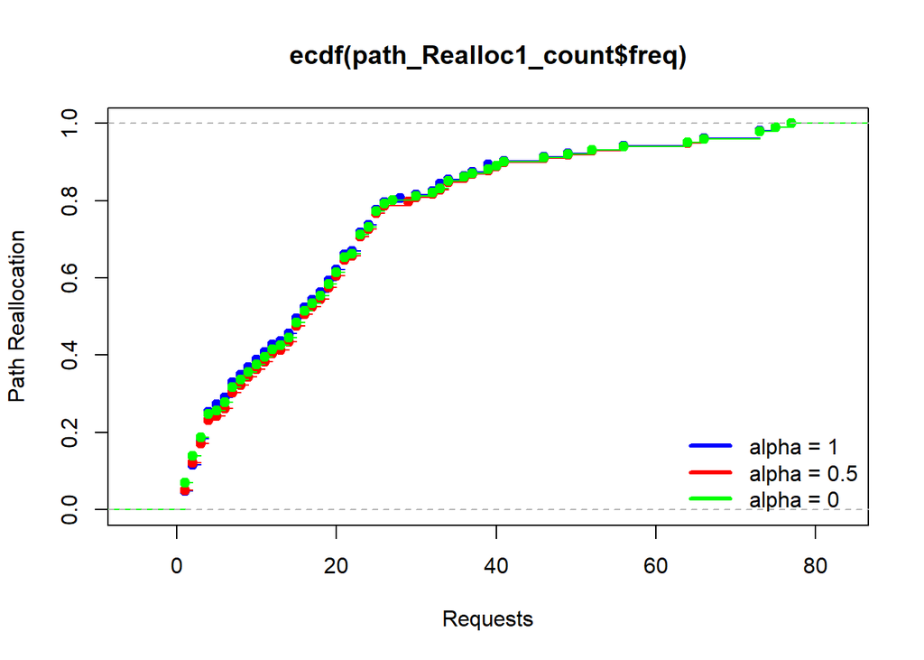

### Número de Realocação de Servidor por Requisição

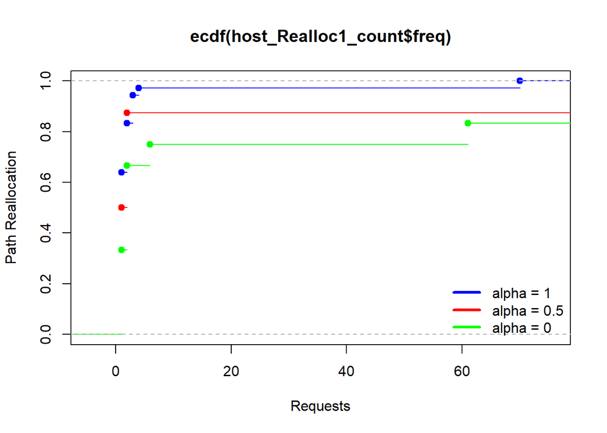

### Número de Realocação de Enlaces por Evento

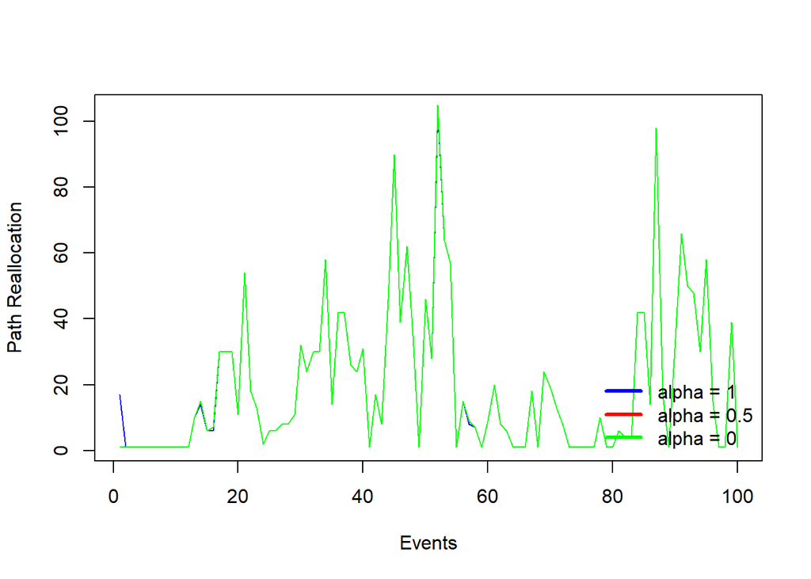

### Significância entre amostras (Teste T não pareado).

*Um valor de p menor que 0.05 indica que a diferença é estatisticamente significativa.*

A diferença entre alfa 1 e alfa 0.5 **não é** estatisticamente significativa. Valor de p: 0.9702733.

A diferença entre alfa 1 e alfa 0 **não é** estatisticamente significativa. Valor de p: 0.9702733.

A diferença entre alfa 0.5 e alfa 0 **não é** estatisticamente significativa. Valor de p: 1.

### Número de Realocação de Servidor por Evento

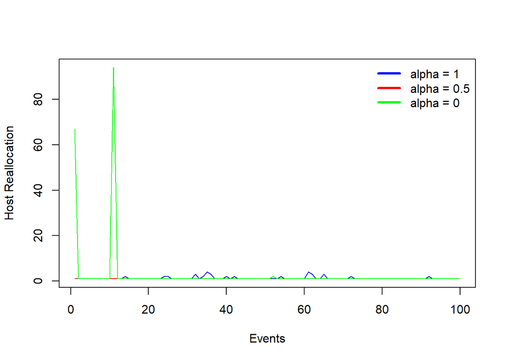

### Significância entre amostras (Teste T não pareado).

*Um valor de p menor que 0.05 indica que a diferença é estatisticamente significativa.*

A diferença entre alfa 1 e alfa 0 **não é** estatisticamente significativa. Valor de p: 0.230894.

A diferença entre alfa 0.5 e alfa 0 **não é** estatisticamente significativa. Valor de p: 0.164336.

### Testes de Correlação Kendall

*Um valor de p próximo de 0 indica fraca correlação e próximo a 1 forte correlação.*

Correlação entre migração de servidores e caminhos. Valor de p: 0.1259322.

Correlação entre carga média dos enlaces e migração de caminhos. Valor de p: 0.1153116.